# Introduction to sensiPhy

Gustavo Paterno; Caterine Penone; Gijsbert Werner

2017-01-13

### Sensitivity Analysis for Comparative Methods

#### Functions for sensitivity analysis

The **sensiPhy** package provides simple functions to perform sensitivity analysis in phylogenetic comparative methods. It uses several simulation methods to estimate the impact of different types of uncertainty on PGLS models:

1. Species Sampling uncertainty (sample size; influential species and clades)
2. Phylogenetic uncertainty
3. Data uncertainty (intraspecific variation and measurement error)

sensiPhy functions use a common syntax that combines the type of uncertainty and the type of model: *uncertainty.type_phylm* (for linear regressions) or *uncertainty.type_phyglm* (for logistic regressions).

| **Function** | **Uncertainty** | **Model** |
| --- | --- | --- |
| samp_phylm | sample size | linear regression |
| samp_phyglm | sample size | logistic regression |
| influ_phylm | influential species | linear regression |
| influ_phyglm | influential species | logistic regression |
| clade_phylm | influential clade | linear regression |
| clade_phyglm | influential clades | logistic regression |
| tree_phylm | phylogenetic uncertain | linear regression |
| tree_phylm | phylogenetic uncertain | logistic regression |
| intra_phylm | Data uncertainty | linear regression |
| intra_phylm | Data uncertainty | logistic regression |

Mandatory arguments of these functions include: `function(formula , data, phy, ...)`

#### Additional functions

| **Function** | Description |
| --- | --- |
| match_dataphy | Match data and phylogeny based on model formula |
| miss.phylo.d | Calculates the phylogenetic signal for missing data |

The following examples describes the basic usage of **sensiPhy** functions.

## Examples:

Loading the package and data

```r
set.seed(1234)
library(sensiPhy)

### Loading data:
data(alien)
data(primates) # see ?alien & ?primates for details about the data.
```

## 1.Sampling uncertainty

### 1.1 Sensitivity analysis for sampling size:

The `samp_phylm` function performs analyses of sensitivity to species sampling by randomly removing species and detecting the effects on parameter estimates in a phylogenetic linear regression.

- Additional arguments:  
  **breaks:** A vector containing the percentages of species to remove  
  **times:** The number of times species are randomly deleted for each break

```r
# run analysis:
samp <- samp_phylm(log(gestaLen) ~ log(adultMass), phy = alien$phy[[1]],
                   data = alien$data, times = 10, track = F)
```

```
## Used dataset has  84  species that match data and phylogeny
```

```r
# You can change the number of repetitions and break intervals:
samp2 <- samp_phylm(log(gestaLen) ~ log(adultMass), phy = alien$phy[[1]], track = F,
                    data = alien$data, times = 100, breaks = c(0.1, 0.2, 0.3, 0.4))
```

```
## Used dataset has  84  species that match data and phylogeny
```

```r
# You can change the phylogenetic model:
samp <- samp_phylm(log(gestaLen) ~ log(adultMass), phy = alien$phy[[1]],
                   data = alien$data, model = "kappa", track = F)
```

```
## Used dataset has  84  species that match data and phylogeny
```

```r
# Check results:
knitr::kable(summary(samp))
```

```
## 150 simulations saved, see output$samp.model.estimates to acess all simulations
```

| % Species Removed | % Significant Intercepts | Mean Intercept Change (%) | Mean sDFintercept | % Significant Slopes | Mean Slope Change (%) | Mean sDFslope |
| --- | --- | --- | --- | --- | --- | --- |
| 10 | 100 | 1.966667 | -0.1970550 | 100 | 3.686667 | 0.2384257 |
| 20 | 100 | 4.103333 | -0.1311984 | 100 | 7.776667 | 0.3018753 |
| 30 | 100 | 5.003333 | -0.4332537 | 100 | 9.896667 | 0.6141183 |
| 40 | 100 | 6.873333 | -0.3434639 | 100 | 13.570000 | 0.7573968 |
| 50 | 100 | 9.203333 | -0.5721201 | 100 | 18.300000 | 1.3674361 |

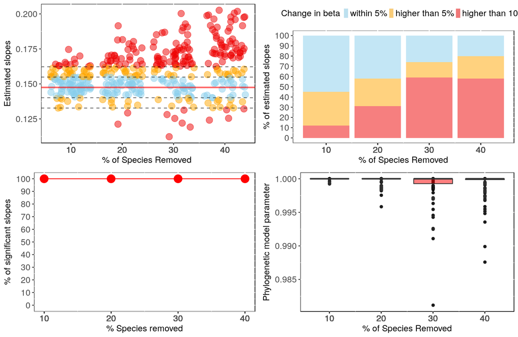

```r
# Visual diagnostics
sensi_plot(samp2)
```

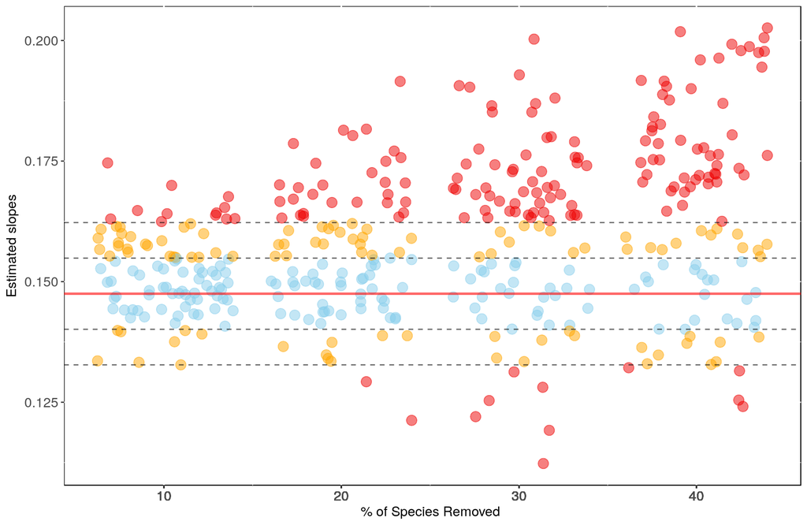

```r
# You can specify which graph and parameter ("slope" or "intercept") to print:
sensi_plot(samp2, graphs = 1)
```

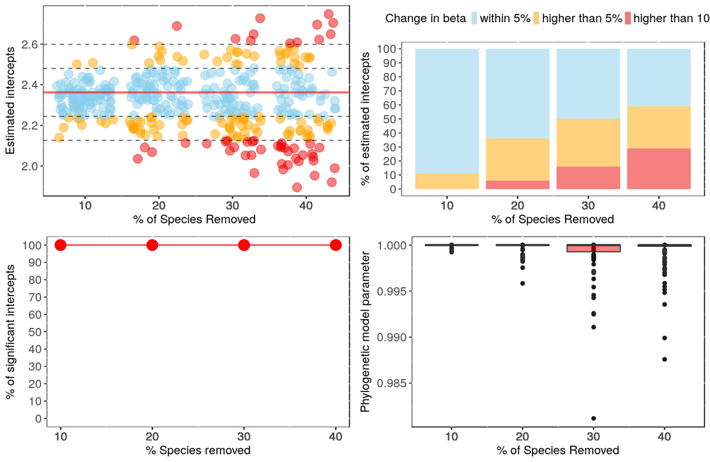

```r
sensi_plot(samp2, param = "intercept")
```

### 1.2 Sensitivity analysis for influential species:

The function `influ_phylm` performs leave-one-out deletion analyis for phylogenetic linear regression, and detects influential species.

```r
# run analysis:
influ <- influ_phylm(log(gestaLen) ~ log(adultMass), phy = alien$phy[[1]],
                     data = alien$data, track = F)
```

```
## Used dataset has  84  species that match data and phylogeny
```

```r
# To check summary results:
summary(influ)
```

```
## $`Influential species for the Slope`
## [1] "Ovis_ammon"         "Ovis_aries"         "Equus_hemionus"
## [4] "Camelus_bactrianus" "Axis_porcinus"      "Axis_axis"
##
## $`Slope Estimates`
##      Species removed     Slope      DFslope Change(%)         Pval
## 1         Ovis_ammon 0.1585335  0.011033226       7.5 1.465612e-10
## 2         Ovis_aries 0.1567383  0.009238004       6.3 2.949203e-10
## 3     Equus_hemionus 0.1384028 -0.009097490       6.2 3.326380e-09
## 4 Camelus_bactrianus 0.1400746 -0.007425680       5.0 2.741126e-09
## 5      Axis_porcinus 0.1546280  0.007127723       4.8 3.792296e-10
## 6          Axis_axis 0.1531949  0.005694542       3.9 4.646006e-10
##
## $`Influential species for the Intercept`
## [1] "Ornithorhynchus_anatinus" "Ovis_ammon"
## [3] "Ovis_aries"               "Axis_porcinus"
## [5] "Sorex_cinereus"
##
## $`Intercept Estimates`
##            Species removed Intercept DFintercept Change(%)         Pval
## 1 Ornithorhynchus_anatinus  2.459667  0.09744173       4.1 4.298004e-10
## 2               Ovis_ammon  2.275301 -0.08692386       3.7 2.181632e-09
## 3               Ovis_aries  2.289397 -0.07282803       3.1 2.279349e-09
## 4            Axis_porcinus  2.306031 -0.05619439       2.4 1.890367e-09
## 5           Sorex_cinereus  2.412289  0.05006331       2.1 7.463555e-10
```

```r
# Most influential species
influ$influential.species
```

```
## $influ.sp.slope
## [1] "Ovis_ammon"         "Ovis_aries"         "Equus_hemionus"
## [4] "Camelus_bactrianus" "Axis_porcinus"      "Axis_axis"
##
## $influ.sp.intercept
## [1] "Ornithorhynchus_anatinus" "Ovis_ammon"
## [3] "Ovis_aries"               "Axis_porcinus"
## [5] "Sorex_cinereus"
```

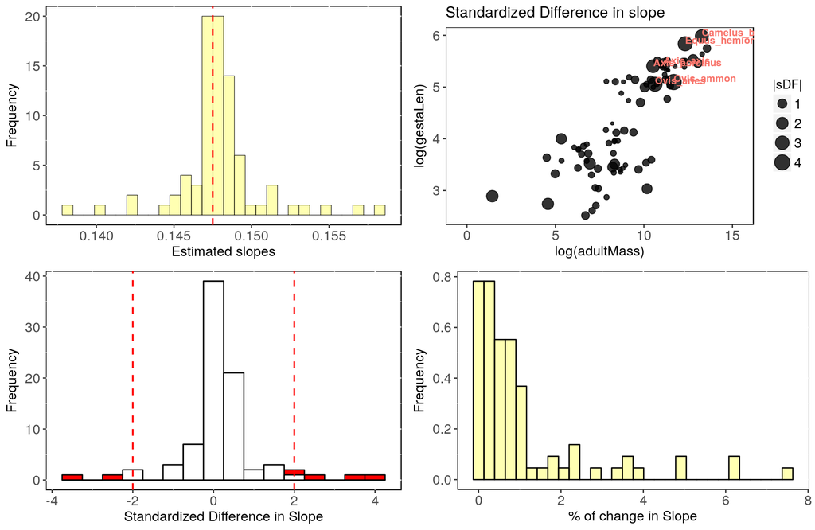

```r
# Visual diagnostics
sensi_plot(influ)
```

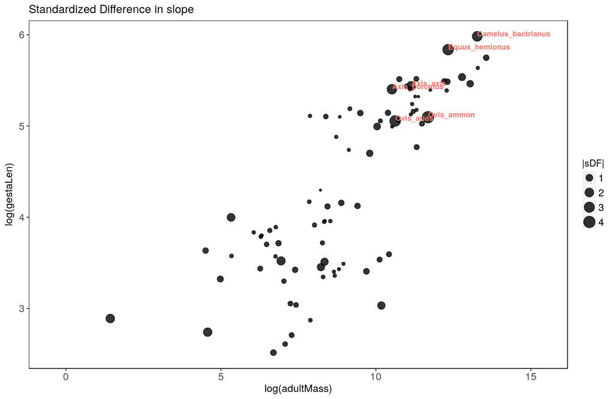

```r
# Check most influential species on the original regression plot:
sensi_plot(influ, graphs = 2)
```

### 1.3 Sensitivity analysis for influential clades (Primates data):

The function `clade_phylm` estimate the impact on model estimates of phylogenetic linear regression after removing clades from the analysis.

- Additional arguments:  
  **clade.col:** The name of a column in the provided data frame with clades specification (a character vector with clade names).  
  **n.species:** Minimum number of species in the clade in order to include this clade in the leave-one-out deletion analysis. Default is 5.  
  **times:** The number of repetition for the randomization test

```r
# Original data set:
knitr::kable(head(primates$data))
```

|  | family | adultMass | sexMaturity | homeRange |
| --- | --- | --- | --- | --- |
| Cercopithecus_diana | Cercopithecidae | 4370 | 1977.08 | 1.27 |
| Cercopithecus_neglectus | Cercopithecidae | 5320 | 1809.79 | 0.06 |
| Cercopithecus_pogonias | Cercopithecidae | 3580 | 1472.16 | 1.17 |
| Cercopithecus_cephus | Cercopithecidae | 3440 | 1320.08 | 0.24 |
| Cercopithecus_ascanius | Cercopithecidae | 3540 | 1490.41 | 0.17 |
| Cercopithecus_mitis | Cercopithecidae | 5040 | 1779.37 | 0.11 |

```r
# run analysis:
clade <- clade_phylm(log(sexMaturity) ~ log(adultMass), phy = primates$phy[[1]],
                     data = primates$data, clade.col = "family", times = 99, track = F)
```

```
## Used dataset has  95  species that match data and phylogeny
```

```r
# To check summary results and most influential clades:
summary(clade)
```

```
## $Slope
##     clade.removed N.species     slope     DFslope Change (%)         Pval
## 3 Cercopithecidae        32 0.3075424  0.05706804       22.8 5.742404e-11
## 2         Cebidae        19 0.2199214 -0.03055296       12.2 7.285954e-07
## 1  Callitrichidae         9 0.2260405 -0.02443393        9.8 5.285826e-08
## 4       Lemuridae         8 0.2581974  0.00772303        3.1 1.323367e-09
##   m.null.slope Pval.randomization
## 3    0.2799503         0.18181818
## 2    0.2644762         0.00000000
## 1    0.2580067         0.01010101
## 4    0.2553345         0.33333333
##
## $Intercept
##     clade.removed N.species intercept DFintercept Change (%)         Pval
## 3 Cercopithecidae        32  4.496911 -0.38912425        8.0 5.742404e-11
## 2         Cebidae        19  5.051216  0.16518056        3.4 7.285954e-07
## 1  Callitrichidae         9  5.072203  0.18616707        3.8 5.285826e-08
## 4       Lemuridae         8  4.829880 -0.05615518        1.1 1.323367e-09
##   m.null.intercept Pval.randomization
## 3         4.652871          0.2323232
## 2         4.769680          0.0000000
## 1         4.825502          0.0000000
## 4         4.847405          0.3535354
```

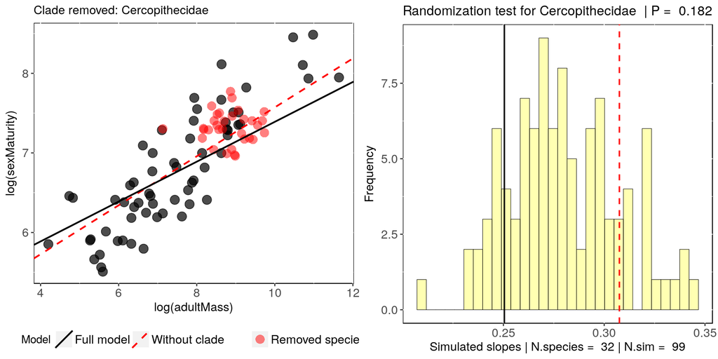

```r
# Visual diagnostics for clade removal:
sensi_plot(clade, "Cercopithecidae")
```

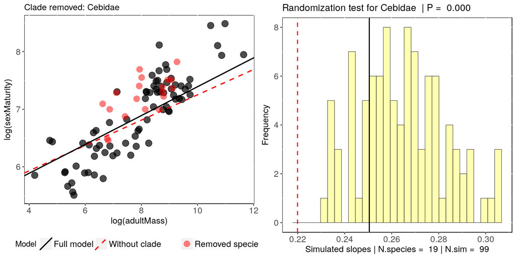

```r
sensi_plot(clade, "Cebidae")
```

## 2.Phylogenetic uncertainty:

The function `tree_phylm` performs Phylogenetic linear regression evaluating uncertainty in trees topology.

- Additional arguments:  
  **times:** Number of times to repeat the analysis with n different trees picked randomly in the multiPhylo file. If NULL, times = 2

### 2.1 Sensitivity analysis for phylogenetic trees:

```r
# This analysis needs a multiphylo file:
class(alien$phy)
```

```
## [1] "multiPhylo"
```

```r
alien$phy
```

```
## 101 phylogenetic trees
```

```r
# run PGLS accounting for phylogenetic uncertain:
tree <- tree_phylm(log(gestaLen) ~ log(adultMass), phy = alien$phy,
                   data = alien$data, times = 100, track = F)
```

```
## Used dataset has  84  species that match data and phylogeny
```

```r
# To check summary results:
knitr::kable(summary(tree))
```

|  | mean | CI_low | CI_high |
| --- | --- | --- | --- |
| intercept | 2.326 | 2.319 | 2.334 |
| se.intercept | 0.342 | 0.342 | 0.343 |
| pval.intercept | 0.000 | 0.000 | 0.000 |
| slope | 0.152 | 0.151 | 0.153 |
| se.slope | 0.022 | 0.022 | 0.022 |
| pval.slope | 0.000 | 0.000 | 0.000 |

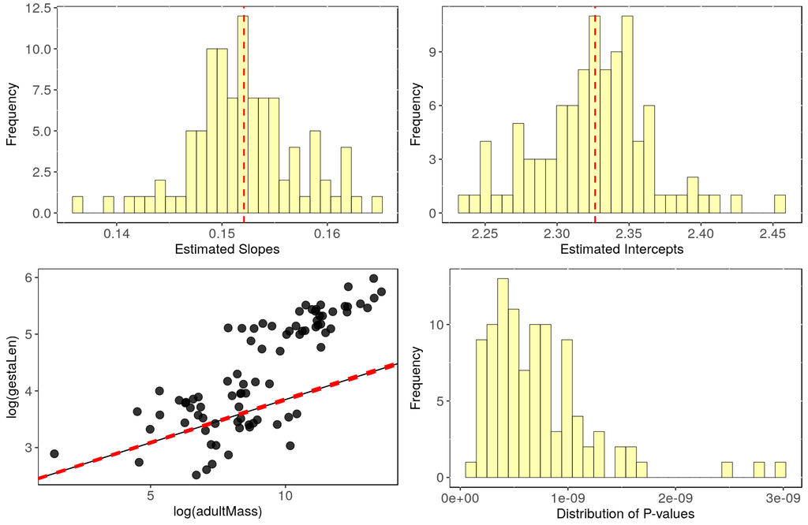

```r
# Visual diagnostics
sensi_plot(tree)
```

## 3.Data uncertainty:

The function `intra_phylm` performs Phylogenetic linear regression evaluating intraspecific variability.

### 3.1 Sensitivity analysis for intraspecific variation and measurement error:

```r
# run PGLS accounting for intraspecific variation:
intra <- intra_phylm(gestaLen ~ adultMass, phy = alien$phy[[1]], track = F,
                     data = alien$data, Vy = "SD_gesta", Vx = "SD_mass",
                     times = 100, x.transf = log, y.transf = log)
```

```
## Used dataset has  84  species that match data and phylogeny
```

```r
# To check summary results:
knitr::kable(summary(intra))
```

|  | mean | CI_low | CI_high |
| --- | --- | --- | --- |
| intercept | 2.390 | 2.359 | 2.421 |
| se.intercept | 0.368 | 0.364 | 0.373 |
| pval.intercept | 0.000 | 0.000 | 0.000 |
| slope | 0.144 | 0.140 | 0.148 |
| se.slope | 0.023 | 0.022 | 0.023 |
| pval.slope | 0.000 | 0.000 | 0.000 |

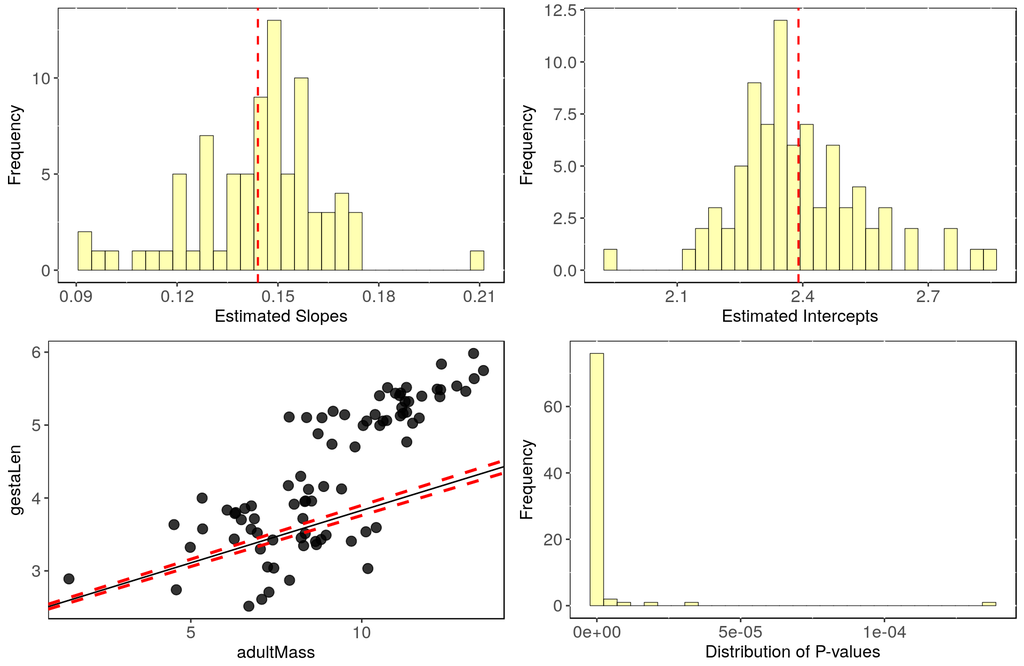

```r
# Visual diagnostics
sensi_plot(intra)
```

## 4. Aditional functions

### 4.1 Phylogenetic signal for missing data

The function `miss.phylo.d` Calculates D statistic (Fritz & Purvis 2010), a measure of phylogenetic signal, for missing data. Missingness is recoded into a binary variable (1=missing, 0=non missing).

```r
# Load caper:
library(caper)
# Load data
data(alien)
knitr::kable(head(alien.data))
```

|  | family | adultMass | gestaLen | homeRange | SD_mass | SD_gesta | SD_range |
| --- | --- | --- | --- | --- | --- | --- | --- |
| Tachyglossus_aculeatus | Tachyglossidae | 4020.767 | 28.375 | 0.9991117 | 1218.29240 | 4.1995 | 0.7922419 |
| Ornithorhynchus_anatinus | Ornithorhynchidae | 1458.208 | 15.000 | 0.1120000 | 180.81779 | 2.1600 | 0.0430000 |
| Ondatra_zibethicus | Cricetidae | 1135.014 | 27.100 | 0.0044500 | 388.17479 | 3.3333 | 0.0000000 |
| Mesocricetus_auratus | Cricetidae | 97.125 | 15.500 | NA | 12.52913 | 0.4960 | NA |
| Castor_canadensis | Castoridae | 18085.634 | 110.000 | NA | 2875.61581 | 13.0900 | NA |
| Chinchilla_lanigera | Chinchillidae | 452.575 | NA | NA | 40.73175 | NA | NA |

```r
data <- alien.data
phy = alien.phy[[1]]

# Test phylogenetic signal for missing data:
homeNAsig <- miss.phylo.d(data, phy, binvar = homeRange)
```

```
## [1] "Percentage of missing data in traits:"
##    family adultMass  gestaLen homeRange   SD_mass  SD_gesta  SD_range
##      0.00      2.13      9.57     44.68      2.13      9.57     44.68
```

```r
print(homeNAsig)
```

```
##
## Calculation of D statistic for the phylogenetic structure of a binary variable
##
##   Data :  data
##   Binary variable :  homeRange
##   Counts of states:  0 = 52
##                      1 = 42
##   Phylogeny :  phy
##   Number of permutations :  1000
##
## Estimated D :  0.9469183
## Probability of E(D) resulting from no (random) phylogenetic structure :  0.336
## Probability of E(D) resulting from Brownian phylogenetic structure    :  0
```

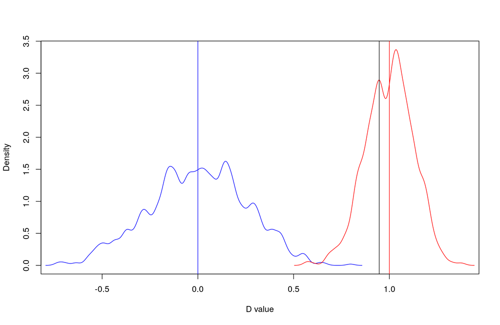

```r
plot(homeNAsig)
```

```r
massNAsig <- miss.phylo.d(data, phy, binvar = adultMass)
```

```
## [1] "Percentage of missing data in traits:"
##    family adultMass  gestaLen homeRange   SD_mass  SD_gesta  SD_range
##      0.00      2.13      9.57     44.68      2.13      9.57     44.68
```

```r
print(massNAsig)
```

```
##
## Calculation of D statistic for the phylogenetic structure of a binary variable
##
##   Data :  data
##   Binary variable :  adultMass
##   Counts of states:  0 = 92
##                      1 = 2
##   Phylogeny :  phy
##   Number of permutations :  1000
##
## Estimated D :  0.8647909
## Probability of E(D) resulting from no (random) phylogenetic structure :  0.362
## Probability of E(D) resulting from Brownian phylogenetic structure    :  0.269
```

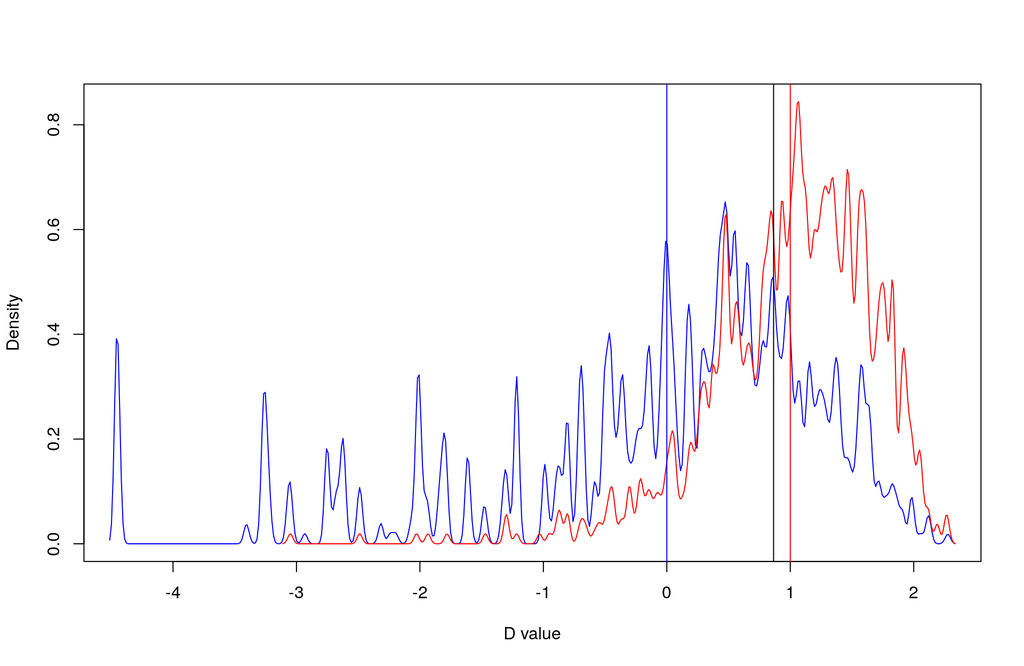

```r
plot(massNAsig)
```

### 4.2 Combine data and phylogeny automatically

The funcion `match_dataphy` combines phylogeny and data to ensure that tips in phylogeny match data and that observations with missing values are removed.

> This function uses all variables provided in the ‘formula’ to match data and phylogeny. To avoid cropping the full dataset, ‘match_dataphy’ searches for NA values only on variables provided by formula. Missing values on other variables, not included in ‘formula’, will not be removed from data.

```r
# Load data:
data(alien)
# Match data and phy based on model formula:
comp.data <- match_dataphy(gestaLen ~ homeRange, data = alien$data, alien$phy[[1]])
```

```
## Used dataset has  49  species that match data and phylogeny
```

```r
# With a `multiphylo` tree:
comp.data2 <- match_dataphy(homeRange ~ homeRange, data = alien$data, alien$phy)
```

```
## Used dataset has  52  species that match data and phylogeny
```

```r
# Check combined data:
knitr::kable(comp.data$data)
```

|  | family | adultMass | gestaLen | homeRange | SD_mass | SD_gesta | SD_range |
| --- | --- | --- | --- | --- | --- | --- | --- |
| Tachyglossus_aculeatus | Tachyglossidae | 4020.767 | 28.375 | 0.9991117 | 1218.29240 | 4.199500 | 0.7922419 |
| Ornithorhynchus_anatinus | Ornithorhynchidae | 1458.208 | 15.000 | 0.1120000 | 180.81779 | 2.160000 | 0.0430000 |
| Ondatra_zibethicus | Cricetidae | 1135.014 | 27.100 | 0.0044500 | 388.17479 | 3.333300 | 0.0000000 |
| Myocastor_coypus | Myocastoridae | 6135.768 | 131.737 | 0.0376000 | 546.08335 | 3.425162 | 0.0156771 |
| Marmota_monax | Sciuridae | 3747.182 | 31.600 | 0.0333582 | 528.35266 | 2.275200 | 0.0429752 |
| Tamiasciurus_hudsonicus | Sciuridae | 209.452 | 35.724 | 0.0117357 | 23.66808 | 3.072264 | 0.0072091 |
| Sciurus_carolinensis | Sciuridae | 538.715 | 44.100 | 0.0270056 | 49.02307 | 0.220500 | 0.0470268 |
| Sciurus_vulgaris | Sciuridae | 649.843 | 40.545 | 0.0818883 | 223.54599 | 3.649050 | 0.1449527 |
| Glis_glis | Gliridae | 146.000 | 27.750 | 0.0030500 | 21.17000 | 2.747250 | 0.0025500 |
| Lepus_arcticus | Leporidae | 4166.869 | 52.000 | 18.9500050 | 145.84042 | 0.988000 | 16.0499950 |
| Lepus_timidus | Leporidae | 3048.556 | 50.133 | 1.0090000 | 408.50650 | 0.100266 | 0.1200000 |
| Lepus_europaeus | Leporidae | 3934.287 | 41.200 | 1.1241550 | 605.88020 | 1.606800 | 1.2592213 |
| Daubentonia_madagascariensis | Daubentoniidae | 2634.074 | 165.750 | 0.2893750 | 213.35999 | 5.304000 | 0.3792628 |
| Ovis_canadensis | Bovidae | 81829.394 | 177.088 | 22.9816067 | 35513.95700 | 5.843904 | 4.4763964 |
| Capra_hircus | Bovidae | 45689.284 | 158.000 | 176.8260900 | 23027.39914 | 8.374000 | 132.8704278 |
| Ammotragus_lervia | Bovidae | 97562.268 | 152.227 | 11.0133367 | 39902.96761 | 18.571694 | 9.3912932 |
| Oreamnos_americanus | Bovidae | 73490.939 | 174.089 | 22.9285800 | 26456.73804 | 14.971654 | 1.0514030 |
| Bos_taurus | Bovidae | 590397.500 | 280.500 | 17.9750000 | 295198.75000 | 2.524500 | 5.7347079 |
| Alces_alces | Cervidae | 461860.313 | 235.840 | 182.3697044 | 115465.07825 | 9.669440 | 226.7850513 |
| Odocoileus_hemionus | Cervidae | 87031.783 | 204.836 | 14.5387520 | 25326.24885 | 3.277376 | 16.2703626 |
| Odocoileus_virginianus | Cervidae | 78331.245 | 205.069 | 2.6916700 | 28199.24820 | 14.764968 | 0.2033300 |
| Axis_axis | Cervidae | 68752.082 | 230.222 | 1.8092367 | 13819.16848 | 11.971544 | 1.3112559 |
| Axis_porcinus | Cervidae | 37015.550 | 221.938 | 0.7000000 | 5108.14590 | 19.308606 | 0.1000000 |
| Cervus_nippon | Cervidae | 66598.688 | 222.553 | 2.9257450 | 38427.44298 | 8.457014 | 2.0742550 |
| Dama_dama | Cervidae | 59049.963 | 229.623 | 2.2787525 | 15884.44005 | 9.184920 | 2.9084486 |
| Moschus_moschiferus | Moschidae | 13357.143 | 171.000 | 0.8516667 | 1215.50001 | 27.189000 | 0.9905414 |
| Antilocapra_americana | Antilocapridae | 46892.188 | 247.944 | 10.9361500 | 6986.93601 | 11.901312 | 5.2666490 |
| Sus_scrofa | Suidae | 82160.027 | 117.735 | 5.7871275 | 31138.65023 | 6.004485 | 6.1376236 |
| Mustela_putorius | Mustelidae | 952.942 | 41.063 | 0.8729158 | 188.68252 | 0.739134 | 0.8328026 |
| Mustela_erminea | Mustelidae | 206.598 | 54.519 | 0.2205200 | 98.13405 | 19.408764 | 0.3400689 |
| Mustela_nivalis | Mustelidae | 90.777 | 37.891 | 0.3641075 | 37.40012 | 4.433247 | 0.5252465 |
| Mephitis_mephitis | Mephitidae | 2573.499 | 64.717 | 2.0949033 | 707.71222 | 2.653397 | 1.4576314 |
| Procyon_lotor | Procyonidae | 7232.221 | 63.911 | 7.1197650 | 2256.45295 | 2.045152 | 3.8152350 |
| Canis_latrans | Canidae | 12197.470 | 61.821 | 39.7382275 | 2110.16231 | 1.978272 | 37.1539830 |
| Nyctereutes_procyonoides | Canidae | 4636.990 | 61.450 | 1.7072350 | 978.40489 | 2.396550 | 0.8172350 |
| Vulpes_vulpes | Canidae | 5077.005 | 52.343 | 7.1448013 | 964.63095 | 3.978068 | 16.6391120 |
| Vulpes_lagopus | Canidae | 4260.696 | 52.413 | 19.6376689 | 1218.55906 | 1.048260 | 12.0364612 |
| Herpestes_javanicus | Herpestidae | 720.714 | 47.233 | 0.2462257 | 178.01636 | 2.645048 | 0.2516805 |
| Desmana_moschata | Talpidae | 428.875 | 46.250 | 0.0045000 | 49.32062 | 1.248750 | 0.0000000 |
| Erinaceus_europaeus | Erinaceidae | 865.896 | 35.556 | 0.1438589 | 282.28210 | 2.417808 | 0.1420654 |
| Sorex_cinereus | Soricidae | 4.198 | 18.000 | 0.0046864 | 0.44079 | 0.000000 | 0.0000000 |
| Trichosurus_vulpecula | Phalangeridae | 2665.563 | 17.660 | 0.0450433 | 455.81127 | 1.130240 | 0.0108214 |
| Bettongia_gaimardi | Potoroidae | 1680.472 | 20.880 | 0.4533350 | 18.48519 | 0.730800 | 0.0033350 |
| Macropus_rufogriseus | Macropodidae | 16242.858 | 30.182 | 0.2436667 | 2192.78583 | 3.410566 | 0.1470518 |
| Macropus_robustus | Macropodidae | 24879.172 | 34.333 | 1.6569700 | 7861.81835 | 0.480662 | 0.9497399 |
| Macropus_giganteus | Macropodidae | 33630.005 | 36.385 | 1.8885950 | 15268.02227 | 0.254695 | 2.4557433 |
| Phascolarctos_cinereus | Phascolarctidae | 7752.538 | 32.775 | 0.0150000 | 2209.47333 | 3.080850 | 0.0075000 |
| Perameles_gunnii | Peramelidae | 810.000 | 12.375 | 0.0302500 | 59.94000 | 0.210375 | 0.0124574 |
| Didelphis_marsupialis | Didelphidae | 1182.023 | 13.600 | 0.4161250 | 177.30345 | 0.734400 | 0.4894138 |

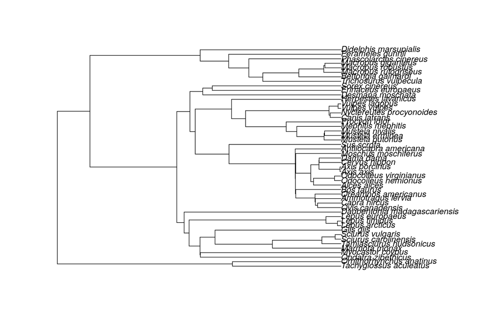

```r
# Check phy:
plot(comp.data$phy)
```

```r
# See species dropped from phy or data:
comp.data$dropped
```

```
##  [1] "Mesocricetus_auratus"     "Castor_canadensis"
##  [3] "Hystrix_brachyura"        "Chinchilla_lanigera"
##  [5] "Marmota_bobak"            "Tamias_townsendii"
##  [7] "Atlantoxerus_getulus"     "Sciurus_niger"
##  [9] "Sciurus_aureogaster"      "Oryctolagus_cuniculus"
## [11] "Macaca_arctoides"         "Macaca_mulatta"
## [13] "Macaca_fascicularis"      "Ovis_ammon"
## [15] "Ovis_aries"               "Hemitragus_jemlahicus"
## [17] "Capra_ibex"               "Rupicapra_rupicapra"
## [19] "Ovibos_moschatus"         "Gazella_subgutturosa"
## [21] "Saiga_tatarica"           "Bubalus_bubalis"
## [23] "Tragelaphus_strepsiceros" "Capreolus_capreolus"
## [25] "Rangifer_tarandus"        "Rusa_timorensis"
## [27] "Cervus_elaphus"           "Rusa_unicolor"
## [29] "Camelus_bactrianus"       "Equus_hemionus"
## [31] "Mustela_sibirica"         "Mustela_lutreola"
## [33] "Neovison_vison"           "Nasua_nasua"
## [35] "Lycalopex_griseus"        "Felis_catus"
## [37] "Pseudocheirus_peregrinus" "Bettongia_lesueur"
## [39] "Macropus_eugenii"         "Macropus_parma"
## [41] "Petrogale_lateralis"      "Petrogale_penicillata"
## [43] "Thylogale_billardierii"   "Potorous_tridactylus"
## [45] "Lasiorhinus_latifrons"
```